# Data Analysis Skill Test

Ihorana Cuco

04/12/2020

## Case 2

```r
summary(brasil_comex)
```

```
##       date              product             state             country
##  Min.   :1997-01-01   Length:117965      Length:117965      Length:117965
##  1st Qu.:2007-02-01   Class :character   Class :character   Class :character
##  Median :2012-10-01   Mode  :character   Mode  :character   Mode  :character
##  Mean   :2011-06-24
##  3rd Qu.:2016-09-01
##  Max.   :2019-12-01
##      type              route                tons                usd
##  Length:117965      Length:117965      Min.   :      0.0   Min.   :  0.000
##  Class :character   Class :character   1st Qu.:    124.9   1st Qu.:  0.072
##  Mode  :character   Mode  :character   Median :   2000.0   Median :  0.720
##                                        Mean   :  14536.8   Mean   :  4.813
##                                        3rd Qu.:  13534.0   3rd Qu.:  3.900
##                                        Max.   :1798445.6   Max.   :900.000
##      year              month
##  Length:117965      Length:117965
##  Class :character   Class :character
##  Mode  :character   Mode  :character
##
##
##
```

# Show the evolution of total monthly and total annual exports from Brazil (all states and to everywhere) of ‘soybeans’, ‘soybean oil’ and ‘soybean meal’

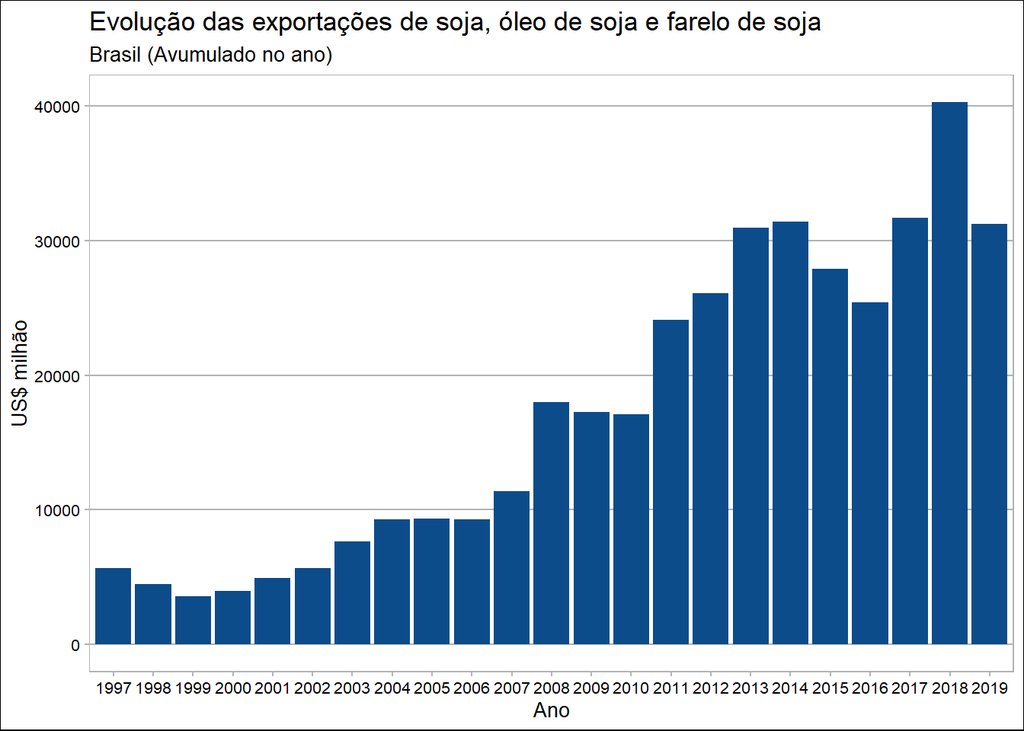

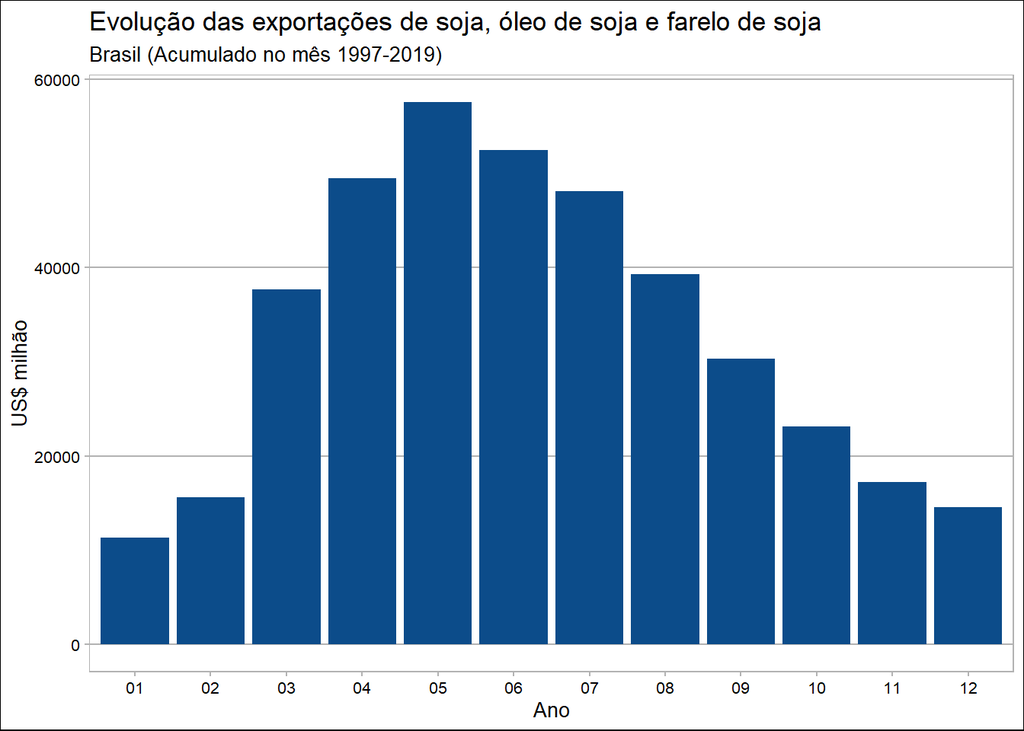

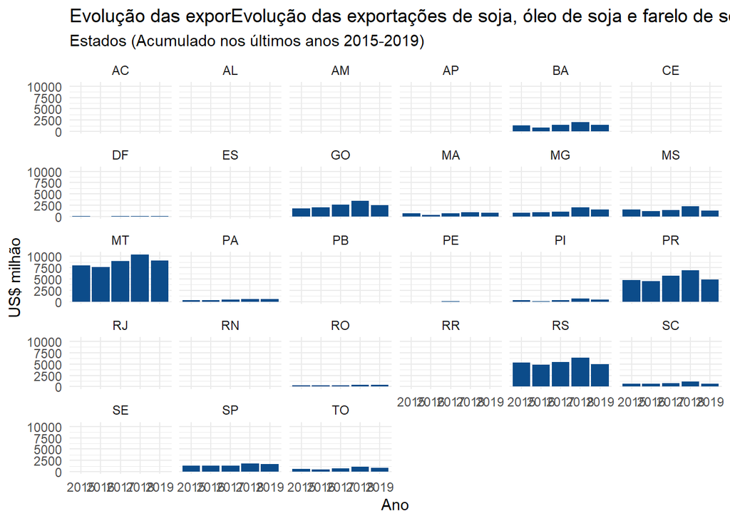

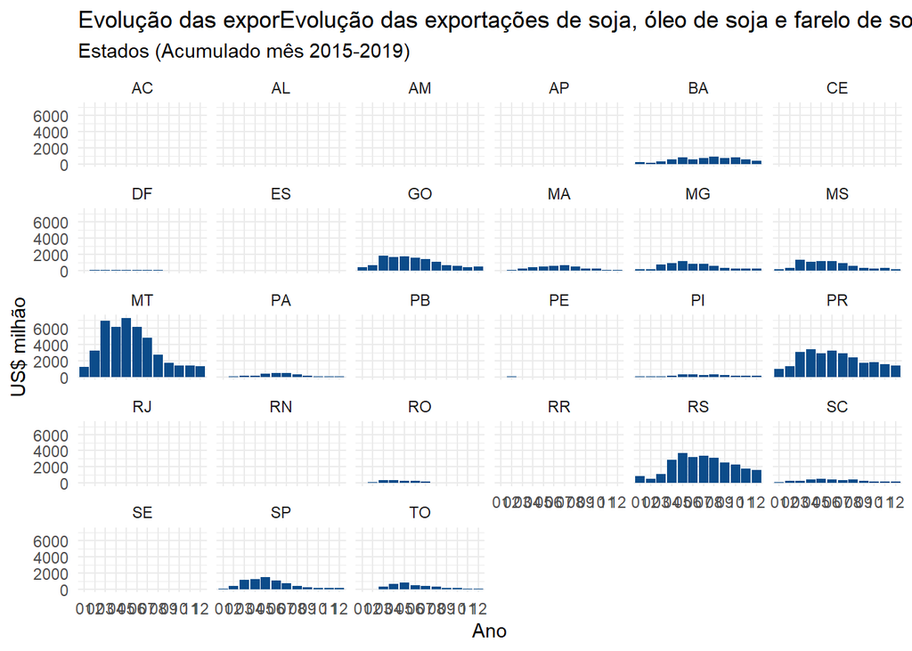

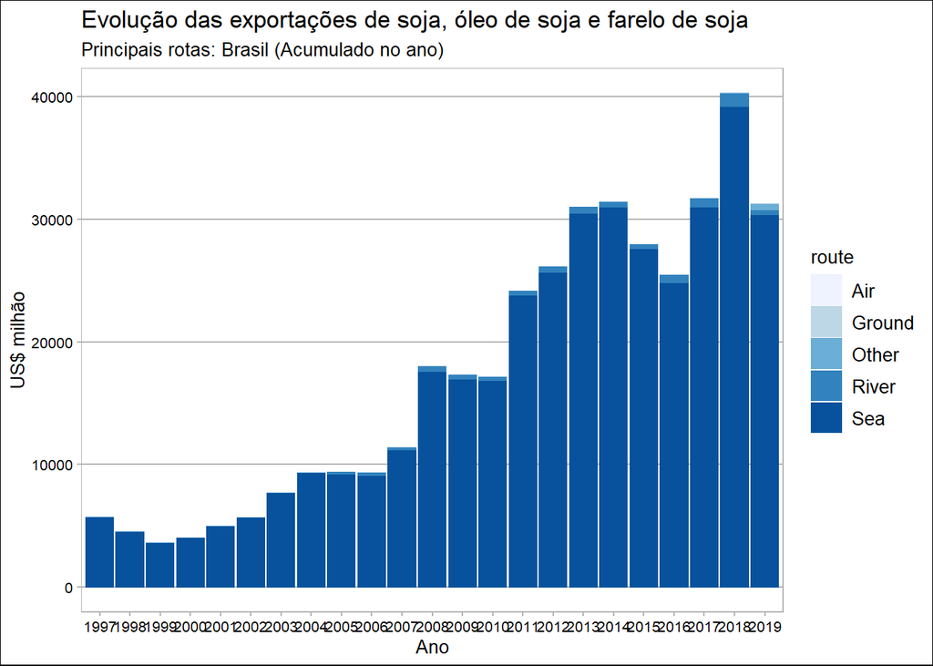

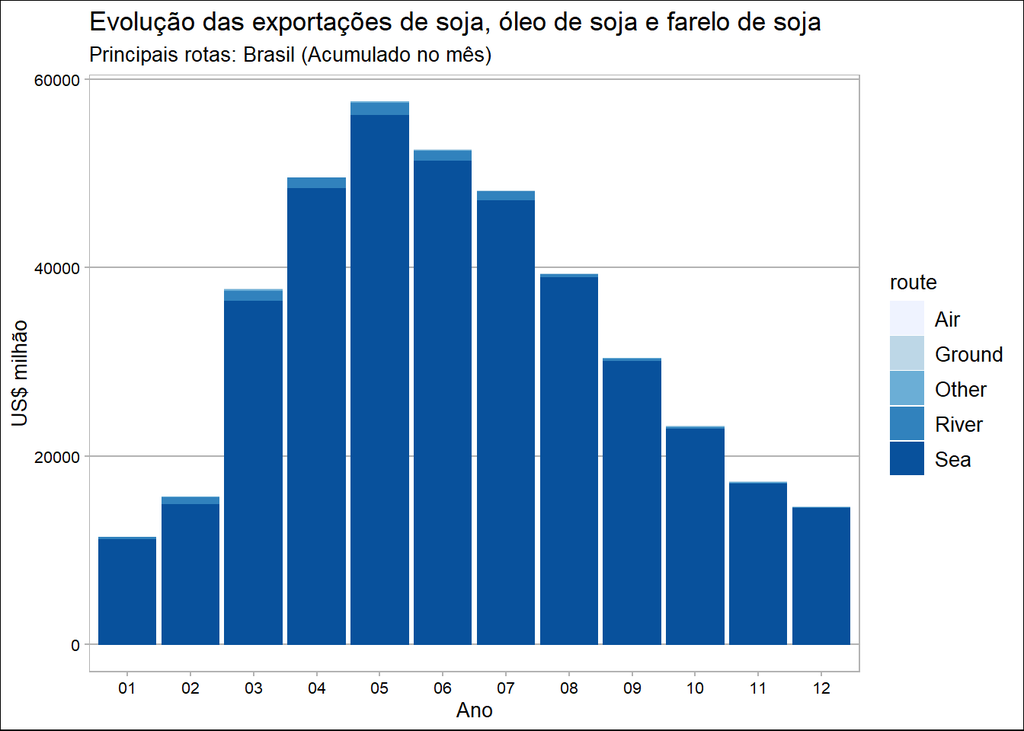

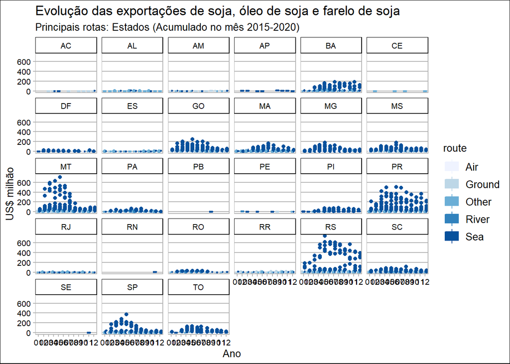

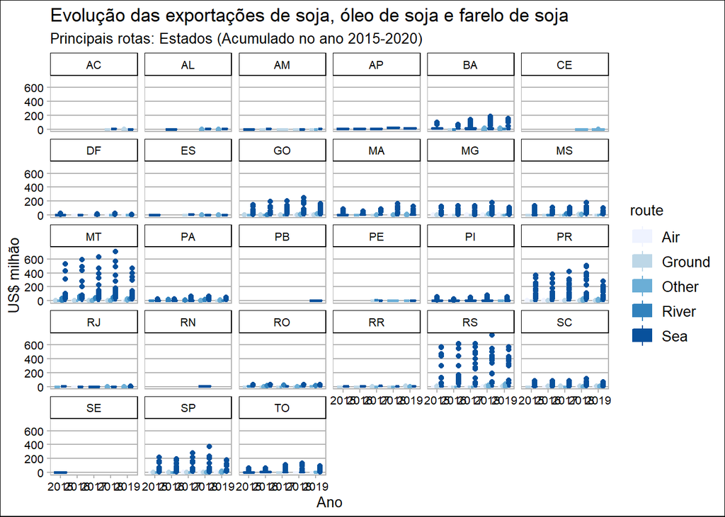

### Resposta: De acordo com o acumulado no ano, as evoluções da exportações no Brasil para os soja, farelo de soja e óleo de soja são ascendentes, com maior alta em 2018. Para os meses, percebe-se uma tendencia de aumento a partir de março e queda posterior a partir de maio.No caso dos Estados, entre os anos de 2015 a 2019, a tendencia também é de aumento. O destaque fica com os o Mato Grasso, o Rio Grande do Sul e o Paraná. Com relação aos meses do ano, também pode-se perceber uma tendencia de alta entre maior e junho.As principais rotas ficaram com: Sea e River.

# What are the 3 most important products exported by Brazil in the last 5 years?

[figure not shown]

```r
brasil_comex %>%
  filter(product %in% c("soybean_meal", "soybeans", "sugar")) %>%

  filter(type %in% "Export") %>%
  filter(year %in% c("2015", "2016", "2017", "2018",
                     "2019")) %>%
  ggplot() +
  aes(x = product, fill = product) +
  geom_bar() +
  scale_fill_brewer(palette = "Paired") +
  labs(x = "Produto", y = "US$ milhão", title = "Evolução dos três principais produtos da pauta de exportação brasileira nos últimos anos", subtitle = "2015-2019") +
  ggthemes::theme_calc() +
  facet_grid(vars(), vars(year))
```

# What are the main routes through which Brazil have been exporting ‘corn’ in the last few years? Are there differences in the relative importancem of routes depending on the product?

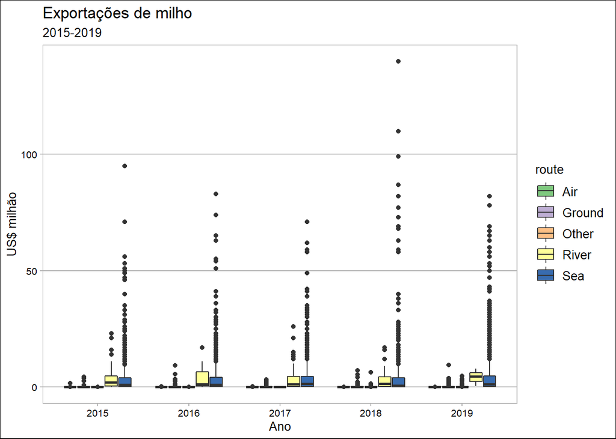

```r
brasil_comex %>%
  filter(product %in% "corn") %>%
  filter(type %in% "Export") %>%
  filter(year %in%
           c("2015", "2016", "2017", "2018", "2019")) %>%
  ggplot() +
  aes(x = year, y = usd, fill = route) +
  geom_boxplot() +
  scale_fill_brewer(palette = "Accent") +
  labs(x = "Ano", y = "US$ milhão", title = "Exportações de milho ", subtitle = "2015-2019") +
  ggthemes::theme_calc()
```

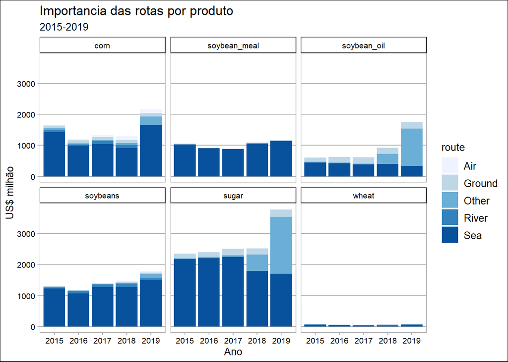

```r
brasil_comex %>%
  filter(type %in% "Export") %>%
  filter(year %in% c("2015", "2016",
                     "2017", "2018", "2019")) %>%
  ggplot() +
  aes(x = year, fill = route) +
  geom_bar() +
  scale_fill_brewer(palette = "Blues") +
  labs(x = "Ano", y = "US$ milhão", title = "Importancia das rotas por produto", subtitle = "2015-2019") +
  ggthemes::theme_calc() +
  facet_wrap(vars(product))
```